# AHP - Choose a Cloud Provider

#### Analytic Hierarchy Process - AHP

The Analytic Hierarchy Process is an international decision-making technique. It is intended to help people or organisations make the right choice in complex decisions. A concrete choice can be made using a prescribed calculation and based on seemingly abstract decision-making criteria.

A value is assigned to the criteria relevant to making the right choice, after which possible solutions are mathematically calculated and determined. Analytic Hierarchy Process is therefore both a psychological and mathematical method.

#### Support

Analytic Hierarchy Process gives insight into why certain choices are made. The more people involved in a decision, the more difficult it is to make. The Analytic Hierarchy Process method has therefore been developed to make the decision-making process transparent and accessible to as many of those involved as possible. This helps to create as much support for the final decision as possible.

Analytic Hierarchy Process is often focused on the group process. The group decides the values of criteria that are important for making a decision. These values are then taken into account in the AHP process.

#### Analytic Hierarchy Process : From abstract to concrete

This method is particularly useful in case of complex decisions involving abstract choices, but for which certain conditions can be set. The Analytic Hierarchy Process method can then be used to assign certain values to the criteria that are important to make the right choice.

Subsequently, the potential solutions are determined and calculated. Analytic Hierarchy Process can help provide concrete choices for abstract decisions.

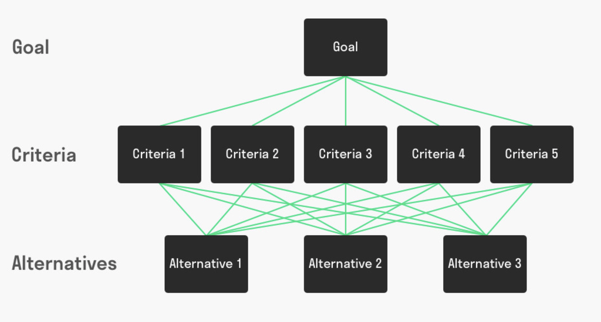

```python
from IPython.display import Image
Image("AHP.png")
```

## AWS vs Azure vs Google – Detailed Cloud Comparison

The battle for cloud dominance is a fierce 3-way race among AWS, Azure, and GCP. While choosing a public cloud service provider, rookies may only focus on the pricing factor. But, there are so many more factors to consider while deciding on who the winner of this cloud battle is.

[figure not shown]

```python
from IPython.display import Image
Image("01-Cloud_logo.png")
```

It’s no longer a question whether to opt for Cloud Computing or not; now, the question is which cloud platform to go for. With Cloud Computing market flooding with numerous cloud providers, AWS, Azure, and Google Cloud Platform stand out proudly as the top three cloud providers. So, how do you decide which one to choose? How do you conclude the big AWS vs Azure vs Google Cloud debate?

AWS vs Azure vs Google Cloud highlights and elaborates the major factors of comparison among AWS, Azure, and GCP. In this Azure vs AWS vs Google Cloud AHP, you’ll be taken through the following criteria:

- Establishment
- Availability Zones
- Market Shares and Growth Rate
- Services
- Pricing Models

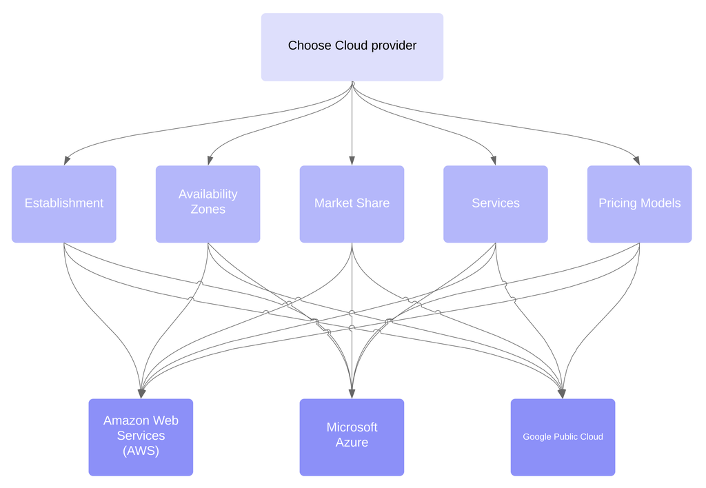

```python
Image("02-AHP_Model.png")
```

```python
import numpy as np
import pandas as pd
from sklearn.preprocessing import Normalizer
```

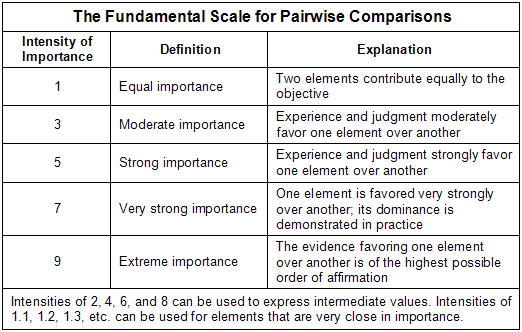

```python
Image("03.png")
```

# RANKING OF CRITERIA

Attributes chosen:

1. Establishment (EST)
2. Availability Zones (AVA)
3. Market Shares and Growth Rate (MAR)
4. Services (SER)
5. Pricing Models (PRI)

```python
criteria = pd.DataFrame({'EST':[    1, 0.33, 0.11,  0.2,0.143],
                         'AVA':[    3,    1,    7,    1,    5],
                         'MAR':[    9,0.143,    1,  0.2, 0.33],
                         'SER':[    5,    1,    5,    1,    3],
                         'PRI':[    7,  0.2,    3, 0.33,    1]},
                         index = ['EST','AVA','MAR', 'SER', 'PRI'])

criteria = criteria.T
criteria
```

|  | EST | AVA | MAR | SER | PRI |
| --- | --- | --- | --- | --- | --- |
| EST | 1.0 | 0.330 | 0.11 | 0.20 | 0.143 |
| AVA | 3.0 | 1.000 | 7.00 | 1.00 | 5.000 |
| MAR | 9.0 | 0.143 | 1.00 | 0.20 | 0.330 |
| SER | 5.0 | 1.000 | 5.00 | 1.00 | 3.000 |
| PRI | 7.0 | 0.200 | 3.00 | 0.33 | 1.000 |

##### Tumačenje

npr:

EST je jednako važan kao i EST  
EST je 1/3 puta važniji od AVA -> AVA je 3 puta važniji od EST

PRI je 7 puta važniji od EST

```python
#       <---9---7---5---3---1---3---5---7---9--->
#     EST                   x                   EST
#     EST                       x               AVA
#     PRI       x                               EST
#
```

```python
#normalizing the critera

criteria['EST'] = criteria['EST']/sum(criteria['EST'])
criteria['AVA'] = criteria['AVA']/sum(criteria['AVA'])
criteria['MAR'] = criteria['MAR']/sum(criteria['MAR'])
criteria['SER'] = criteria['SER']/sum(criteria['SER'])
criteria['PRI'] = criteria['PRI']/sum(criteria['PRI'])


criteria
```

|  | EST | AVA | MAR | SER | PRI |
| --- | --- | --- | --- | --- | --- |
| EST | 0.04 | 0.123457 | 0.006828 | 0.073260 | 0.015096 |
| AVA | 0.12 | 0.374111 | 0.434513 | 0.366300 | 0.527816 |
| MAR | 0.36 | 0.053498 | 0.062073 | 0.073260 | 0.034836 |
| SER | 0.20 | 0.374111 | 0.310366 | 0.366300 | 0.316690 |
| PRI | 0.28 | 0.074822 | 0.186220 | 0.120879 | 0.105563 |

```python
criteria["Rsum"] = criteria.EST + criteria.AVA + criteria.MAR + criteria.SER + criteria.PRI
criteria['Raverage/criteriaVector'] = criteria.Rsum/5
criteria
```

|  | EST | AVA | MAR | SER | PRI | Rsum | Raverage/criteriaVector |
| --- | --- | --- | --- | --- | --- | --- | --- |
| EST | 0.04 | 0.123457 | 0.006828 | 0.073260 | 0.015096 | 0.258640 | 0.051728 |
| AVA | 0.12 | 0.374111 | 0.434513 | 0.366300 | 0.527816 | 1.822740 | 0.364548 |
| MAR | 0.36 | 0.053498 | 0.062073 | 0.073260 | 0.034836 | 0.583667 | 0.116733 |
| SER | 0.20 | 0.374111 | 0.310366 | 0.366300 | 0.316690 | 1.567468 | 0.313494 |
| PRI | 0.28 | 0.074822 | 0.186220 | 0.120879 | 0.105563 | 0.767484 | 0.153497 |

```python
criteria["index"] = criteria.index
```

# VISUALIZING THE RESULTS

```python
import matplotlib.pyplot as plt
import seaborn as sns
```

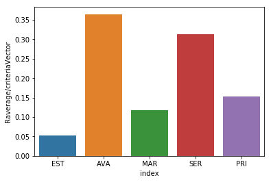

```python
sns.barplot(x = "index", y = 'Raverage/criteriaVector', data=criteria)
```

# ALTERNATIVES

Three alternatives for Cloud Provider:

1. Amazon Web Services - AWS
2. Azure
3. Google Cloud

## Establishment

##### Amazon Web Services

Amazon Web Services is a subsidiary of amazon.com, which provides an on-demand Cloud Computing platform to individuals, companies, and governments on a paid-subscription basis.

Amazon Web Services is the oldest and the most experienced player in the cloud market. As one of the oldest cloud providers, it has established a bigger user base, as well as bigger trust and reliability factors.

AWS was publicly launched in 2006 with service offerings such as Elastic Compute Cloud (EC2), Simple Storage Service (Amazon S3), etc. By 2009, Elastic Block Store (EBS) was made public and services such as Amazon CloudFront, Content delivery network (CDN), and more formally joined the AWS Cloud Computing Service offerings.

##### Microsoft Azure

Microsoft Azure, initially called Azure, was launched in 2010 with the intent to provide a competent Cloud Computing platform for businesses. Azure was renamed as ‘Microsoft Azure’ in 2014, though the name ‘Azure’ is still commonly used. Since its inception, Microsoft Azure has shown a great progress among its competitors.

##### Google Cloud Platform

Google Cloud Platform (GCP), which is offered by Google, is a suite of Cloud Computing services that runs on the same infrastructure that Google uses internally for its end-user products such as Google Search engine, YouTube, and more.

Google Cloud Platform began its journey in 2011, and in less than a decade it has managed to create a good presence in the cloud industry. The initial intent of Google Cloud was to strengthen Google’s own products such as Google Search engine and YouTube. But now, they have also introduced their enterprise services so that anyone can use Google Cloud Platform which shares the same infrastructure as that of Google Search or YouTube.

```python
EST = pd.DataFrame({'AWS':   [    1,    2,    3],
                    'AZURE': [  0.5,    1,    2],
                    'GOOGLE':[ 0.33,  0.5,    1]},

            index = ['AWS','AZURE','GOOGLE'])

EST = EST.T
EST
```

|  | AWS | AZURE | GOOGLE |
| --- | --- | --- | --- |
| AWS | 1.00 | 2.0 | 3.0 |
| AZURE | 0.50 | 1.0 | 2.0 |
| GOOGLE | 0.33 | 0.5 | 1.0 |

```python
# normalizing the critera

EST['AWS'] = EST['AWS']/sum(EST['AWS'])
EST['AZURE'] = EST['AZURE']/sum(EST['AZURE'])
EST['GOOGLE'] = EST['GOOGLE']/sum(EST['GOOGLE'])

EST["Rsum"] = EST.AWS + EST.AZURE + EST.GOOGLE
EST['Raverage/criteriaVector'] = EST.Rsum/3
EST
```

[output not shown]

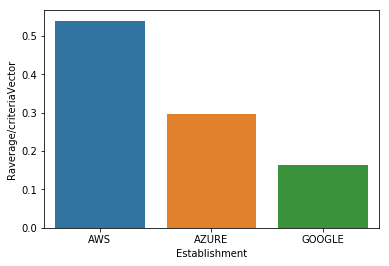

```python
EST['Establishment'] = EST.index
sns.barplot(x = 'Establishment', y = 'Raverage/criteriaVector', data=EST)
```

## Availability Zones

It has been already established that AWS was the earliest in the cloud domain which means that they have had more time to establish and expand their network. So, AWS is hosting in multiple locations worldwide. Azure and GCP are also hosting in multiple locations worldwide, but the difference occurs in the number of their respective availability zones.

- AWS has 66 availability zones with 12 more on the way.
- Azure has 54 regions worldwide and is available in 140 countries all around the world.
- Google Cloud Platform has been made available in 20 regions around the world with 3 more on their way.

```python
AVA = pd.DataFrame({'AWS':   [    1,    5,    9],
                    'AZURE': [  0.2,    1,    2],
                    'GOOGLE':[ 0.11,  0.5,    1]},

            index = ['AWS','AZURE','GOOGLE'])

AVA = AVA.T
AVA
```

|  | AWS | AZURE | GOOGLE |
| --- | --- | --- | --- |
| AWS | 1.00 | 5.0 | 9.0 |
| AZURE | 0.20 | 1.0 | 2.0 |
| GOOGLE | 0.11 | 0.5 | 1.0 |

```python
# normalizing the critera

AVA['AWS'] = AVA['AWS']/sum(AVA['AWS'])
AVA['AZURE'] = AVA['AZURE']/sum(AVA['AZURE'])
AVA['GOOGLE'] = AVA['GOOGLE']/sum(AVA['GOOGLE'])

AVA["Rsum"] = AVA.AWS + AVA.AZURE + AVA.GOOGLE
AVA['Raverage/criteriaVector'] = AVA.Rsum/3
AVA
```

|  | AWS | AZURE | GOOGLE | Rsum | Raverage/criteriaVector |
| --- | --- | --- | --- | --- | --- |
| AWS | 0.763359 | 0.769231 | 0.750000 | 2.282590 | 0.760863 |
| AZURE | 0.152672 | 0.153846 | 0.166667 | 0.473185 | 0.157728 |
| GOOGLE | 0.083969 | 0.076923 | 0.083333 | 0.244226 | 0.081409 |

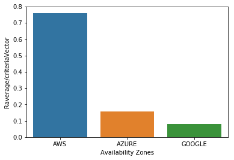

```python
AVA['Availability Zones'] = AVA.index
sns.barplot(x = 'Availability Zones', y = 'Raverage/criteriaVector', data=AVA)
```

## Market Shares and Growth Rate

In terms of cloud market, AWS has been on the top for as long as anyone can remember:

- AWS is leading with around 30 percent of public cloud share in its name.
- Microsoft Azure is on the second place, owning around 16 percent of the worldwide market share.
- Google, on the third place, owns up to 10 percent of the market share worldwide.

Even though both Microsoft Azure and GCP are lagging behind AWS, when it comes to market shares, they have shown tremendous growth rate. As of 2019, GCP has shown a growth rate of 83 percent while Microsoft Azure is at the second place with 75 percent of growth rate and AWS, at the third place, with 41 percent of growth rate.

```python
MAR = pd.DataFrame({'AWS':   [    1,  0.2,0.143],
                    'AZURE': [    5,    1,  0.5],
                    'GOOGLE':[    7,    2,    1]},

            index = ['AWS','AZURE','GOOGLE'])

MAR = MAR.T
MAR
```

|  | AWS | AZURE | GOOGLE |
| --- | --- | --- | --- |
| AWS | 1.0 | 0.2 | 0.143 |
| AZURE | 5.0 | 1.0 | 0.500 |
| GOOGLE | 7.0 | 2.0 | 1.000 |

```python
# normalizing the critera

MAR['AWS'] = MAR['AWS']/sum(MAR['AWS'])
MAR['AZURE'] = MAR['AZURE']/sum(MAR['AZURE'])
MAR['GOOGLE'] = MAR['GOOGLE']/sum(MAR['GOOGLE'])

MAR["Rsum"] = MAR.AWS + MAR.AZURE + MAR.GOOGLE
MAR['Raverage/criteriaVector'] = MAR.Rsum/3
MAR
```

|  | AWS | AZURE | GOOGLE | Rsum | Raverage/criteriaVector |
| --- | --- | --- | --- | --- | --- |
| AWS | 0.076923 | 0.0625 | 0.087036 | 0.226459 | 0.075486 |
| AZURE | 0.384615 | 0.3125 | 0.304321 | 1.001437 | 0.333812 |
| GOOGLE | 0.538462 | 0.6250 | 0.608643 | 1.772104 | 0.590701 |

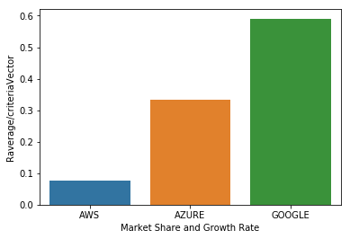

```python
MAR['Market Share and Growth Rate'] = MAR.index
sns.barplot(x = 'Market Share and Growth Rate', y = 'Raverage/criteriaVector', data=MAR)
```

## Services

AWS offers around 200+ services, whereas Azure offers up to 100+ services. Google Cloud, on the other hand, is catching up with Azure and AWS offering around 60+ services.

Service offerings from AWS, Azure, and GCP that come under the domains of compute, database, storage, and networking are mapped below:

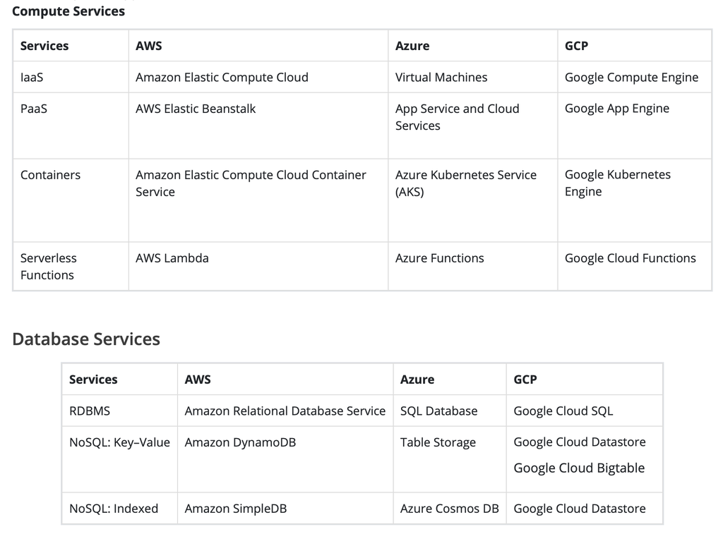

```python
Image("04-Services.png")
```

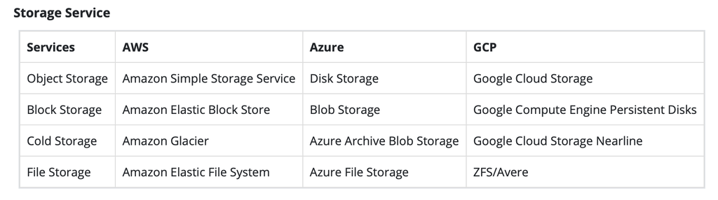

```python
Image("04-Storage.png")
```

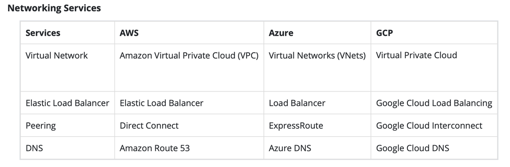

```python
Image("04-Networking.png")
```

```python
SER = pd.DataFrame({'AWS':   [    1,    4,    5],
                    'AZURE': [ 0.25,    1,    2],
                    'GOOGLE':[  0.2,  0.5,    1]},

            index = ['AWS','AZURE','GOOGLE'])

SER = SER.T
SER
```

|  | AWS | AZURE | GOOGLE |
| --- | --- | --- | --- |
| AWS | 1.00 | 4.0 | 5.0 |
| AZURE | 0.25 | 1.0 | 2.0 |
| GOOGLE | 0.20 | 0.5 | 1.0 |

```python
# normalizing the critera

SER['AWS'] = SER['AWS']/sum(SER['AWS'])
SER['AZURE'] = SER['AZURE']/sum(SER['AZURE'])
SER['GOOGLE'] = SER['GOOGLE']/sum(SER['GOOGLE'])

SER["Rsum"] = SER.AWS + SER.AZURE + SER.GOOGLE
SER['Raverage/criteriaVector'] = SER.Rsum/3
SER
```

|  | AWS | AZURE | GOOGLE | Rsum | Raverage/criteriaVector |
| --- | --- | --- | --- | --- | --- |
| AWS | 0.689655 | 0.727273 | 0.625 | 2.041928 | 0.680643 |
| AZURE | 0.172414 | 0.181818 | 0.250 | 0.604232 | 0.201411 |
| GOOGLE | 0.137931 | 0.090909 | 0.125 | 0.353840 | 0.117947 |

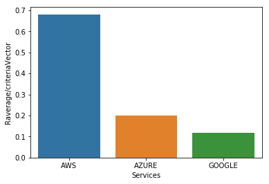

```python
SER['Services'] = SER.index
sns.barplot(x = 'Services', y = 'Raverage/criteriaVector', data=SER)
```

## Pricing Models

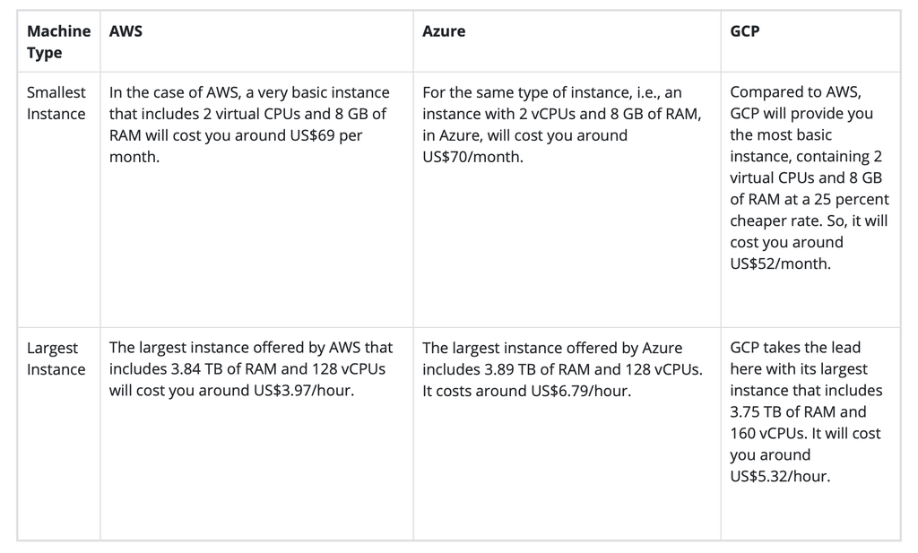

```python
Image("05-Pricing.png")
```

Another point to note here is that AWS recently started offering pay-per-minute billing. Azure already offers pay-per-minute billing, while Google Cloud offers pay-per-second billing models which let users save way more than using AWS or Azure. Google also offers various discounts to help customers save up to 50 percent in some cases when compared to AWS. According to Gartner, ‘Google offers deep discounts and exceptionally flexible contracts to try to win projects from customers.’

```python
PRI = pd.DataFrame({'AWS':   [    1, 0.25, 0.11],
                    'AZURE': [    4,    1, 0.33],
                    'GOOGLE':[    9,    3,    1]},

            index = ['AWS','AZURE','GOOGLE'])

PRI = PRI.T
PRI
```

|  | AWS | AZURE | GOOGLE |
| --- | --- | --- | --- |
| AWS | 1.0 | 0.25 | 0.11 |
| AZURE | 4.0 | 1.00 | 0.33 |
| GOOGLE | 9.0 | 3.00 | 1.00 |

```python
# normalizing the critera

PRI['AWS'] = PRI['AWS']/sum(PRI['AWS'])
PRI['AZURE'] = PRI['AZURE']/sum(PRI['AZURE'])
PRI['GOOGLE'] = PRI['GOOGLE']/sum(PRI['GOOGLE'])

PRI["Rsum"] = PRI.AWS + PRI.AZURE + PRI.GOOGLE
PRI['Raverage/criteriaVector'] = PRI.Rsum/3
PRI
```

|  | AWS | AZURE | GOOGLE | Rsum | Raverage/criteriaVector |
| --- | --- | --- | --- | --- | --- |
| AWS | 0.071429 | 0.058824 | 0.076389 | 0.206641 | 0.068880 |
| AZURE | 0.285714 | 0.235294 | 0.229167 | 0.750175 | 0.250058 |
| GOOGLE | 0.642857 | 0.705882 | 0.694444 | 2.043184 | 0.681061 |

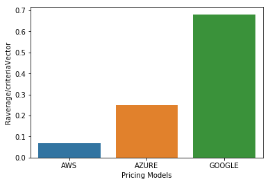

```python
PRI['Pricing Models'] = PRI.index
sns.barplot(x = 'Pricing Models', y = 'Raverage/criteriaVector', data=PRI)
```

# RESULTS

```python
results = pd.DataFrame([EST['Raverage/criteriaVector'],
                        AVA['Raverage/criteriaVector'],
                        MAR['Raverage/criteriaVector'],
                        SER['Raverage/criteriaVector'],
                        PRI["Raverage/criteriaVector"]])

results
```

|  | AWS | AZURE | GOOGLE |
| --- | --- | --- | --- |
| Raverage/criteriaVector | 0.539292 | 0.297424 | 0.163284 |
| Raverage/criteriaVector | 0.760863 | 0.157728 | 0.081409 |
| Raverage/criteriaVector | 0.075486 | 0.333812 | 0.590701 |
| Raverage/criteriaVector | 0.680643 | 0.201411 | 0.117947 |
| Raverage/criteriaVector | 0.068880 | 0.250058 | 0.681061 |

# The final criteria weights

```python
final = pd.DataFrame({"Cloud Provider": ["AWS","AZURE","GOOGLE"],
                      "CriteriaWeights":[results['AWS'].mean(),
                                          results['AZURE'].mean(),
                                          results['GOOGLE'].mean()]})

final
```

|  | Cloud Provider | CriteriaWeights |
| --- | --- | --- |
| 0 | AWS | 0.425033 |
| 1 | AZURE | 0.248087 |
| 2 | GOOGLE | 0.326880 |

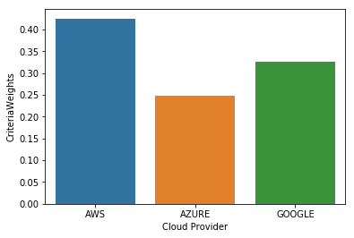

```python
sns.barplot(x = "Cloud Provider", y = 'CriteriaWeights', data=final)
```

## CONCLUSION: Using the AHP method we choose AWS as our cloud provider

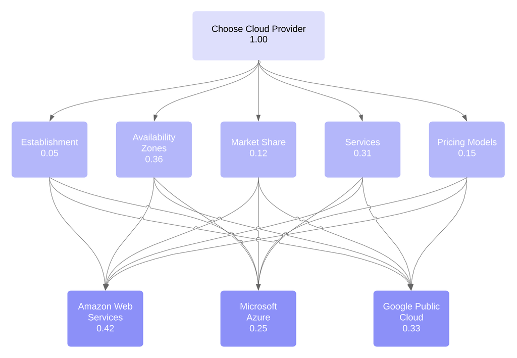

```python
Image("06-AHP_Model_Results.png")
```

[figure not shown]

```python
Image("Winner-AWS.png")
```

SOURCE:

https://intellipaat.com/blog/aws-vs-azure-vs-google-cloud/